# In depth topic Image Processing | Preprocessing of handwritten digits

## ANALYSES AND R PROGRAMMING CODE

### Loading handwritten digits from GitHub.

```r
myurl <- "https://raw.githubusercontent.com/RRighart/RImage/master/arraydat.Rds"
z <- tempfile()
download.file(myurl,z,mode="wb")
dat <- readRDS(z)
file.remove(z)
```

```
## [1] TRUE
```

```r
class(dat)
```

```
## [1] "array"
```

```r
dim(dat)
```

```
## [1]   28   28 2352
```

### R code examples for three dimensional array

```r
v1<-c(0,1,2)
m1<-matrix(c(0:8), nrow=3)
a1<-array(c(0:17), dim=c(3,3,2))
class(v1)
```

```
## [1] "numeric"
```

```r
class(m1)
```

```
## [1] "matrix"
```

```r
class(a1)
```

```
## [1] "array"
```

```r
length(v1)
```

```
## [1] 3
```

```r
dim(m1)
```

```
## [1] 3 3
```

```r
dim(a1)
```

```
## [1] 3 3 2
```

```r
a1[,,1]
```

```
##      [,1] [,2] [,3]
## [1,]    0    3    6
## [2,]    1    4    7
## [3,]    2    5    8
```

```r
a1[,,2]
```

```
##      [,1] [,2] [,3]
## [1,]    9   12   15
## [2,]   10   13   16
## [3,]   11   14   17
```

### Visualize a digit from the image array

Select the 10th element of the third dimension in “dat”. What we see in our output is a matrix of numbers. The numbers in the matrix correspond to intensities of image pixels.

```r
library(gplots)
library(RColorBrewer)
dim(dat[,,10])
```

```
## [1] 28 28
```

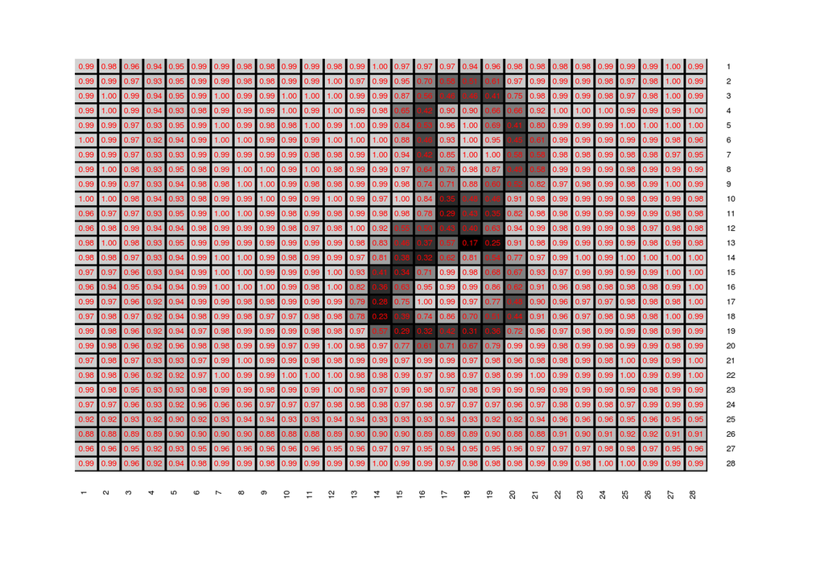

```r
ht<-dat[,,10]
htval <- formatC(ht, format="f", digits=2)
my_palette <- colorRampPalette(c("black", "lightgray"))(n = 50)

par(mar=c(7,4,4,2)+0.1)
heatmap.2(ht, Rowv=FALSE, Colv=FALSE, dendrogram="none", main=NULL, key=FALSE, xlab=NULL, cexRow=0.5, cexCol=0.5, ylab=NULL, col=my_palette, cellnote=htval, trace="none", notecol="red", lhei=c(1,9), lwid=c(0.5,5), notecex=0.5, colsep=1:ncol(ht), rowsep=1:nrow(ht), sepcolor="black", keysize = 1.5, margins=c(6, 6))
```

### Plot a serie of unprocessed images

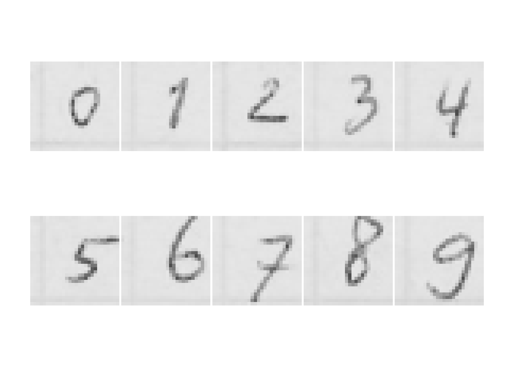

```r
par(mfrow=c(2,5),
        oma = c(3,3,3,3),
        mar = c(0,0.1,0,0.1))
for(i in 12:21){
image(t(apply(dat[, ,i], 2, rev)), col=grey.colors(255), axes=F, asp=1)
}
```

### Negative images

The following function can be used to inverse image intensities.

```r
neg <- function(M,i){
apply(M, 3, max)[i]-M[,,i]
}

mmat<-array(0,dim=dim(dat))
for(i in 1:dim(dat)[3]){
mmat[,,i]<-neg(dat,i)
}
```

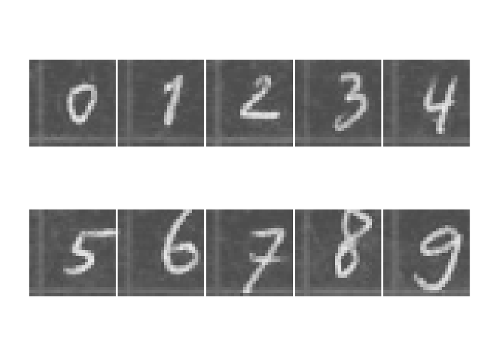

```r
par(mfrow=c(2,5),
        oma = c(3,3,3,3),
        mar = c(0,0.1,0,0.1))
for(i in 12:21){
image(t(apply(mmat[, ,i], 2, rev)), col=grey.colors(255), axes=F, asp=1)
}
```

### Preprocessing steps

A number of preprocessing steps can be taken: *Scaling*, to bring the intensities between 0-1, *Threshold* images, to remove background noise, *Centralize* images, to get the most essential infos in the middle, *Frame* to 24x24, to remove borders.

```r
#scale
range01 <- function(M){(M-min(M))/(max(M)-min(M))}
scmat<-array(0,dim=dim(mmat))
for(i in 1:dim(mmat)[3]){
scmat[,,i]<-range01(mmat[,,i])
}

#threshold
thresh <- function(M){ifelse(M<0.2, 0, M)}
thmat<-thresh(scmat)

# centralize
bmat<-array(0,dim=dim(thmat))
for(i in 1:dim(thmat)[3]){
temp<-thmat[,,i]
w<-temp[apply(temp,1,mean)>0,apply(temp,2,mean)>0]
if(is.null(dim(w))) next
if(dim(w)[1]<4) next
if(dim(w)[2]<4) next
if(dim(w)[1]>26) next
if(dim(w)[2]>26) next
bim<-matrix(rep(0,28*28),nrow=28)
ly=floor(((dim(bim)[1]-dim(w)[1])/2)+0.5)
uy=ly+dim(w)[1]-1
lx=floor(((dim(bim)[2]-dim(w)[2])/2)+0.5)
ux=lx+dim(w)[2]-1
bim[c(ly:uy),c(lx:ux)]<-w
bmat[,,i]<-bim
}

# Frame to 24x24
sfr<-bmat[c(3:26), c(3:26), ]
```

Display the preprocessed images

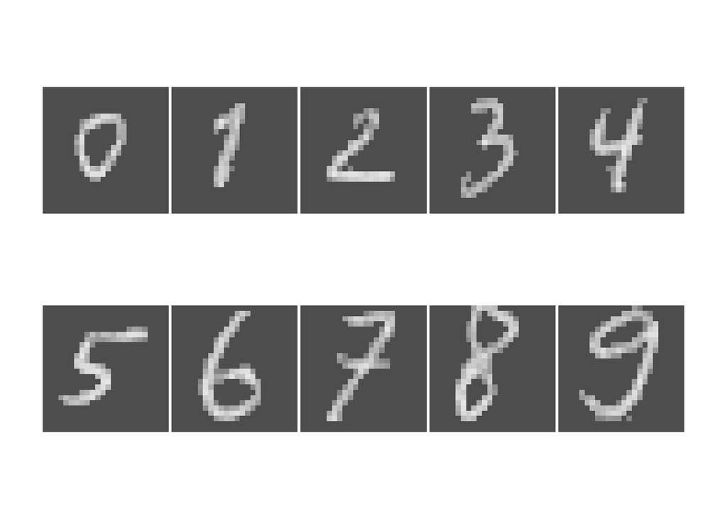

```r
par(mfrow=c(2,5),
        oma = c(3,3,3,3),
        mar = c(0,0.1,0,0.1))
for(i in 12:21){
image(t(apply(sfr[, ,i], 2, rev)), col=grey.colors(255), axes=F, asp=1)
}
```

# QUIZ QUESTIONS AND ANSWERS

### Quiz Question I

In one of the preprocessing steps scaling between 0-1 was proposed. Use R to check the minimum and maximum intensity values in the mmat array, which is *before* the scaling preprocessing step.

**Answer**

If one wants to check minimum and maximum value in every digit, then the `apply` function would work. In the following code, apply is used over the third dimension and the resulting minimum and maximum values for every digit are written to a vector:

```r
minm<-apply(mmat, 3, min)
maxm<-apply(mmat, 3, max)
head(minm, 10)
```

```
##  [1] 0 0 0 0 0 0 0 0 0 0
```

```r
head(maxm, 10)
```

```
##  [1] 0.1772976 0.9156892 0.7829662 0.7560118 0.7242890 0.8650004 0.7801611
##  [8] 0.7915288 0.8832725 0.8335826
```

One could also calculate a single minimum and maximum value across *all* digits:

```r
summary(mmat)
```

```
##    Min. 1st Qu.  Median    Mean 3rd Qu.    Max.
## 0.00000 0.01199 0.02560 0.08044 0.06300 0.99350
```

### Quiz Question II

To appreciate the variance of 10 different handwritten digits of the digit „0“, plot them yourself in a 2x5 frame.

**Answer**

Unfortunately, no labels were given for these data, so we can not subset the data for the given label “0”.

What we need to do is to identify manually the index for each digit and finally only select those that we want to display.

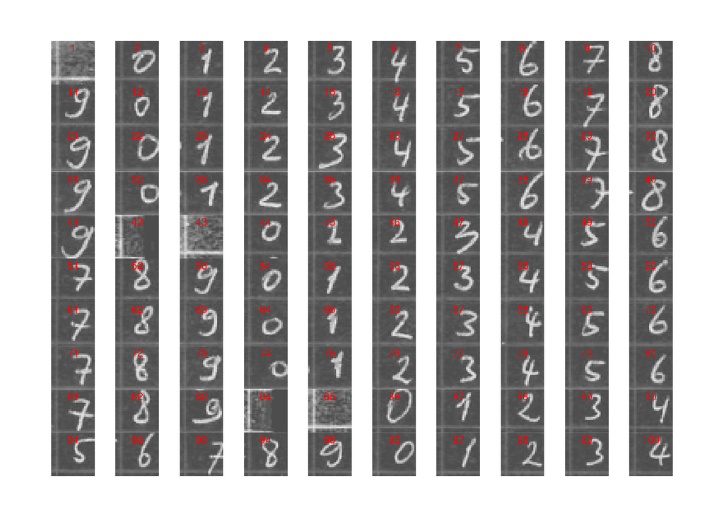

```r
par(mfrow=c(10,10),
        oma = c(3,3,3,3),
        mar = c(0,0.1,0,0.1))
for(i in 1:100){
image(t(apply(mmat[, ,i], 2, rev)), col=grey.colors(255), axes=F, asp=1)
mtext(i, cex=0.6, col="red", side=3, line=-1)
}
```

Now we know the indices that belong to the digit “0”, we can use them to display only those.

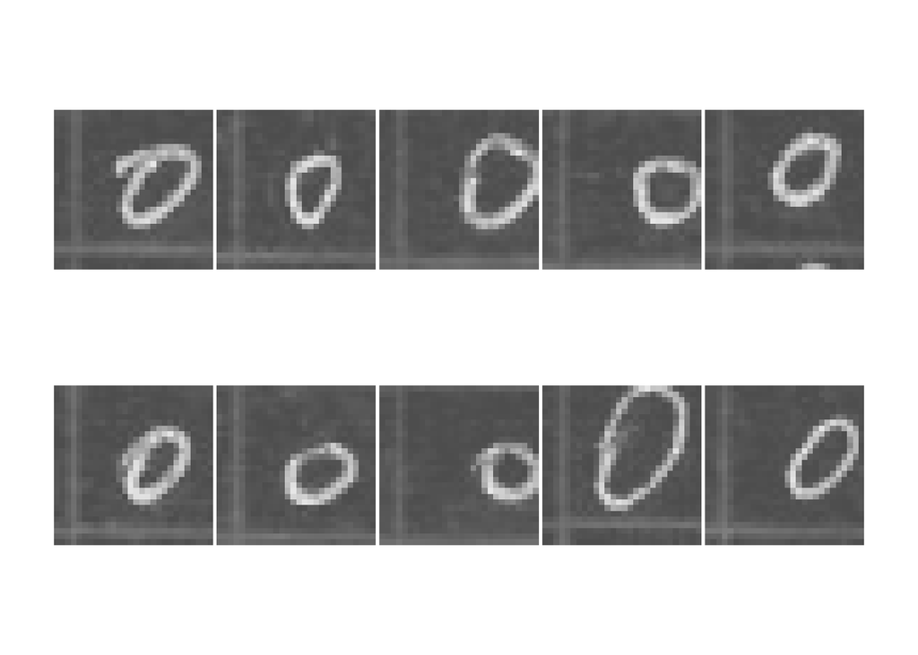

```r
par(mfrow=c(2,5),
        oma = c(3,3,3,3),
        mar = c(0,0.1,0,0.1))
for(i in c(2,12,22,32,44,54,64,74,86,96)){
image(t(apply(mmat[, ,i], 2, rev)), col=grey.colors(255), axes=F, asp=1)
}
```

As this is laborious, it is always preferable to have the labels whenever possible. For those interested, the labels can be found at my GitHub page in the repository “Digits”: https://rrighart.github.io/Digits/

### CONTACT

If you have any questions, please do not hesitate to contact me: rrighart@googlemail.com